# Apuntes GGPLOT2 I

Pilar Amat Rodrigo

02/07/2018

## **GGPLOT2**

INFO:

https://www.datacamp.com/courses/data-visualization-with-ggplot2-1

This GGPLOT2_I:

**Intro** // **Data** // **Aesthetics** // **Geometries** // **qplot**

The GGPLOT2_II:

**Statistics** // **Best Practices** // **Case study**

The GGPLOT2_III:

**Advanced plots** // **ggplot2 internals**

This GGPLOT2_I:

### **Intro**

The library has to be required:`ggplot2`. The dataset that we will use is `mtcars`, `iris`, `Diamonds`

The `mtcars` dataset contains information about 32 cars from 1973 Motor Trend magazine. The `iris` dataset with information about some flowers. The `Diamonds` contains information on the prices and various metrics of 50,000 diamonds.

```r
library(ggplot2)
```

Essential grammar for graphics:

| Element | Description | Variables |
| --- | --- | --- |
| `Data` | The dataset being plotted | Variales we choose |
| `Aesthetics` | The scales onto which we map our data | x,y-axis, color, fill ,size, labels, shape |
| `Geometries` | The visual elements used for our data (shape) | point, line, histogram, bar, boxplot |
| `Facets` | Multiples plots | columns, rows |
| `Statistics` | Representation of our data to aid understanding | binning, smoothing, descriptive, inferential |
| `Coordinates` | The space on which the data will be plotted | cartesial, fixed, polar, limits |
| `Themes` | Non data ink |  |

Let’s see a few examples with the datase: `Diamonds`

```r
str(diamonds)
```

[output not shown]

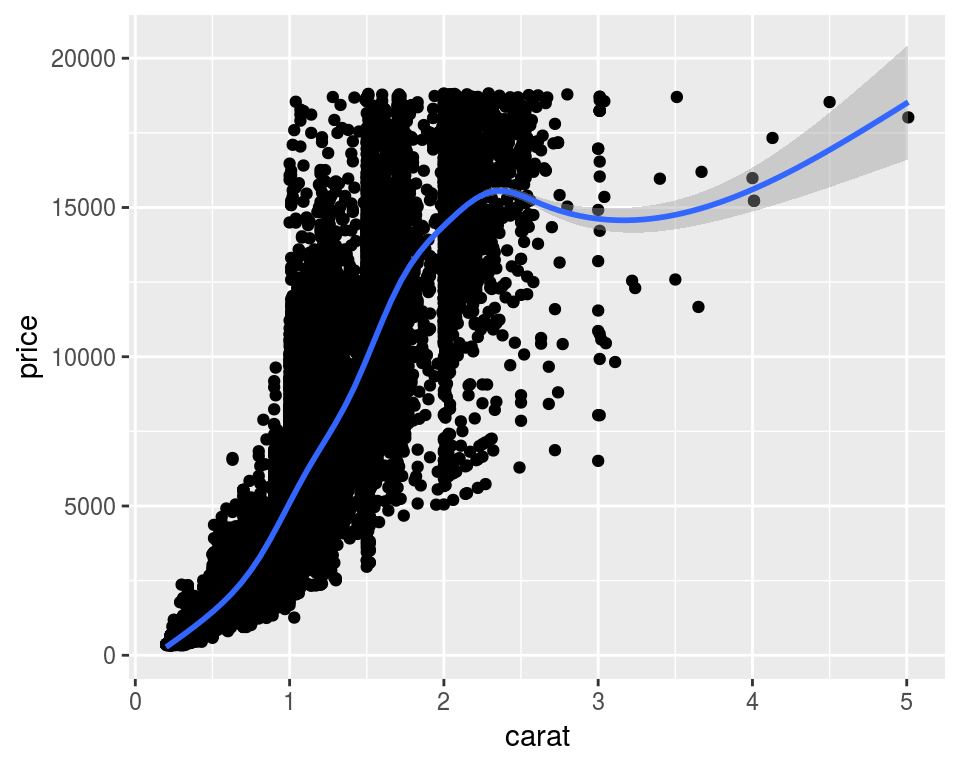

```r
# Represent a scatter plot comparing the variable carat (dimension) vs the price.
ggplot(diamonds, aes(x = carat, y = price)) +
  geom_point() +
  geom_smooth()
```

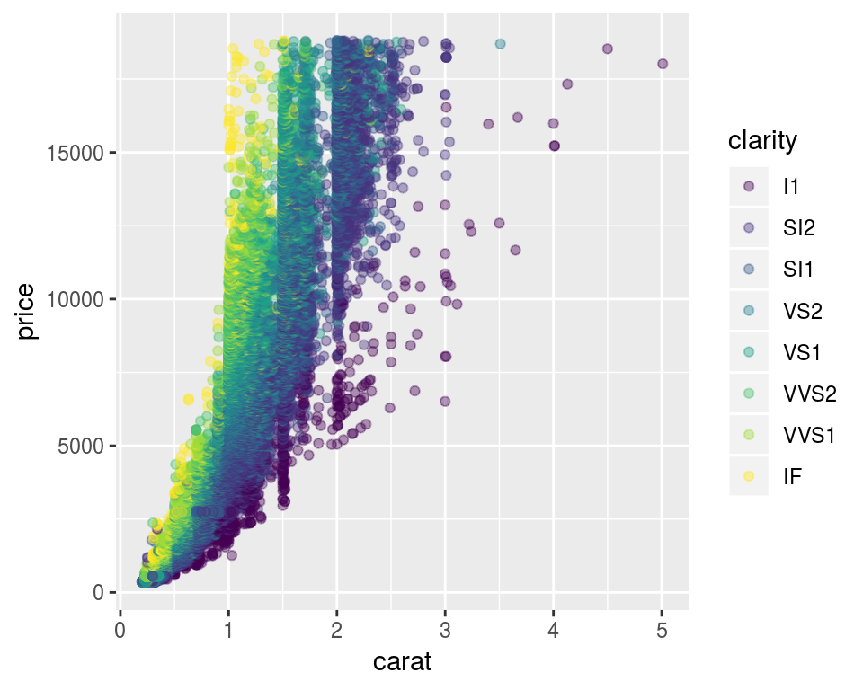

```r
# PLot diamonds setting the color depending on the clarity and making points 40% transparent
ggplot(diamonds, aes(x = carat, y = price, color= clarity)) +
  geom_point(alpha=0.4)
```

To set a property of a geom to a single value, pass it as an argument. To give the property different values for each row of data, pass it as an aesthetic.

`se` removes the shadow.

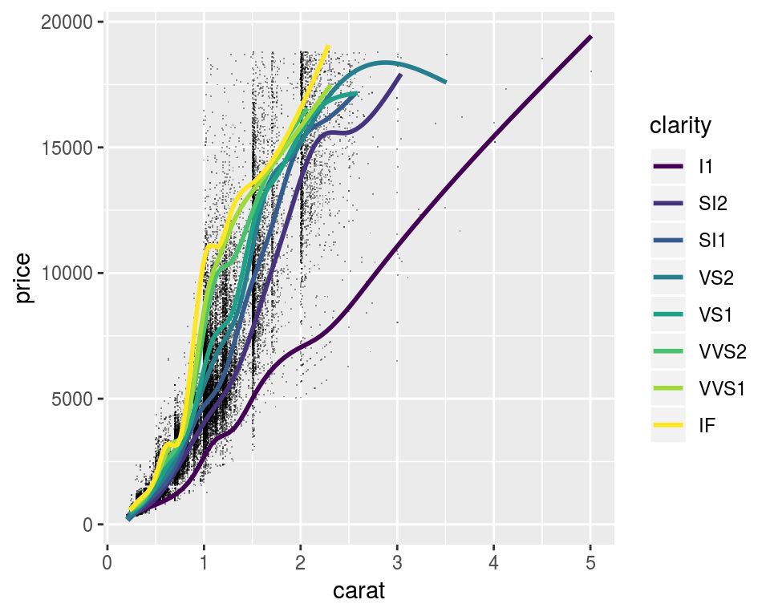

```r
ggplot(diamonds, aes(x = carat, y = price))+
              geom_point(alpha=0.4, shape=".")+
              geom_smooth(aes(col = clarity), se = FALSE)
```

**4 reasons why** it’s better to use ggplot2 vs the base package:

1.Plot doesn’t get redrawn if we add more variables or complexity.

2.The plot is indeed an image.

3.Uses different formulas depending on the type of plot.

4.Need to manually add legend.

### **Data**

Depending on the type of plot we need we should pre arrange the data.

Let’s see an example using `iris` dataset. Steps: 1) Explore the data set 2) Merge or combine columns to tidy :every row is an observation and every column is a variable. 3)Plot the last set.

```r
str(iris)
```

```
## 'data.frame':    150 obs. of  5 variables:
##  $ Sepal.Length: num  5.1 4.9 4.7 4.6 5 5.4 4.6 5 4.4 4.9 ...
##  $ Sepal.Width : num  3.5 3 3.2 3.1 3.6 3.9 3.4 3.4 2.9 3.1 ...
##  $ Petal.Length: num  1.4 1.4 1.3 1.5 1.4 1.7 1.4 1.5 1.4 1.5 ...
##  $ Petal.Width : num  0.2 0.2 0.2 0.2 0.2 0.4 0.3 0.2 0.2 0.1 ...
##  $ Species     : Factor w/ 3 levels "setosa","versicolor",..: 1 1 1 1 1 1 1 1 1 1 ...
```

```r
library(tidyr)
library(dplyr)
```

```r
iris_tidy<-iris %>% gather(key="Part.measure", value = "Values", -Species) %>% separate(col = Part.measure, into = c("Part", "Measure"), sep = "\\.")
str(iris_tidy)
```

```
## 'data.frame':    600 obs. of  4 variables:
##  $ Species: Factor w/ 3 levels "setosa","versicolor",..: 1 1 1 1 1 1 1 1 1 1 ...
##  $ Part   : chr  "Sepal" "Sepal" "Sepal" "Sepal" ...
##  $ Measure: chr  "Length" "Length" "Length" "Length" ...
##  $ Values : num  5.1 4.9 4.7 4.6 5 5.4 4.6 5 4.4 4.9 ...
```

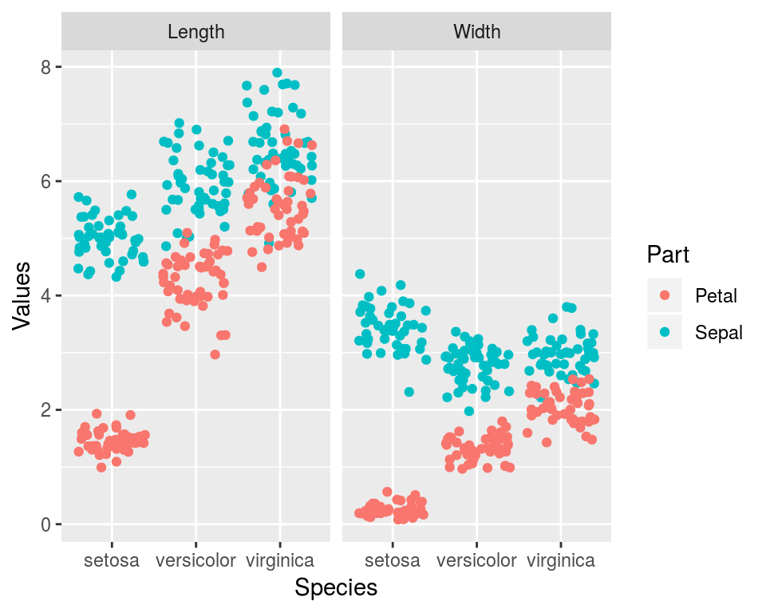

```r
library(ggplot2)
ggplot(iris_tidy, aes(x = Species, y = Values, col = Part)) +
  geom_jitter() +
  facet_grid(. ~ Measure)
```

To get this other plot:

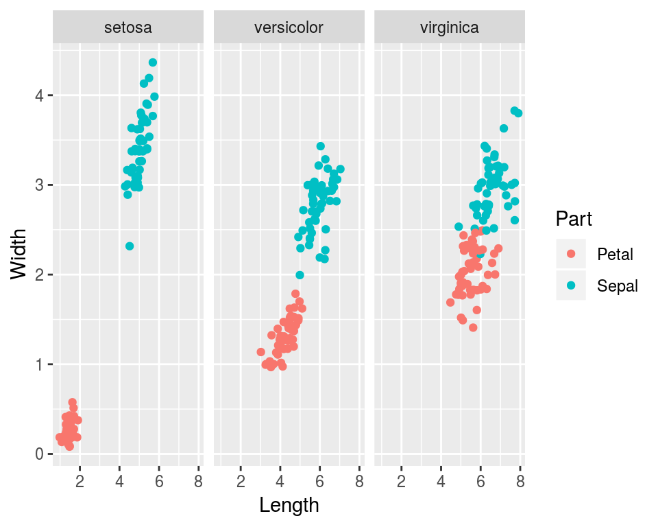

It was necessary to reorganise data first, in this case it was crucial to ad a id column to have a unique identifier.

```
##   Species id  Part Length Width
## 1  setosa  1 Petal    1.4   0.2
## 2  setosa  1 Sepal    5.1   3.5
## 3  setosa  2 Petal    1.4   0.2
## 4  setosa  2 Sepal    4.9   3.0
## 5  setosa  3 Petal    1.3   0.2
## 6  setosa  3 Sepal    4.7   3.2
```

### **Aesthetics**

Can be added in the aes() or inside a geom_()

| Aesthetics | Description | Details | Type of data |
| --- | --- | --- | --- |
| x | x-axis |  |  |
| y | y-axis |  |  |
| colour | of dots, outlines of other shapes | Better Categorical Data |  |
| size | Diameter of points, thickness of lines | 1,2,3…. |  |
| fill | Fill Colour |  |  |
| alpha | Transparency | 0-1, 0.4 = 40% de Color |  |
| linetype | Line Dash pattern | 1-6 | Better Categorical Data |
| labels | Text on a plot or axes |  | Categorical Data |
| shape | Shapes | 1=empty circle, 2=piramid,3=+, 4=x,5=diamond, 21=fill&color Values 1-25 | Categorical Data |
| ——- | ———— | ———- | ——– |

**Shapes**: a value from 1-25. Shapes 1-20 can only accept a color aesthetic, but shapes 21-25 have both a color and a fill aesthetic. See the pch argument in par() for further discussion.

**hexadecimal colours**: Hexadecimal, literally “related to 16”, is a base-16 alphanumeric counting system. Individual values come from the ranges 0-9 and A-F. This means there are 256 possible two-digit values (i.e. 00 - FF). Hexadecimal colours use this system to specify a six-digit code for Red, Green and Blue values (“#RRGGBB”) of a colour (i.e. Pure blue: “#0000FF”, black: “#000000”, white: “#FFFFFF”). R can accept hex codes as valid colours.

Notice that adding more aesthetics to your plot is not always a good idea. Adding aesthetic mappings to a plot will increase its complexity, and thus decrease its readability.

Some plots aren’t very simple to read:

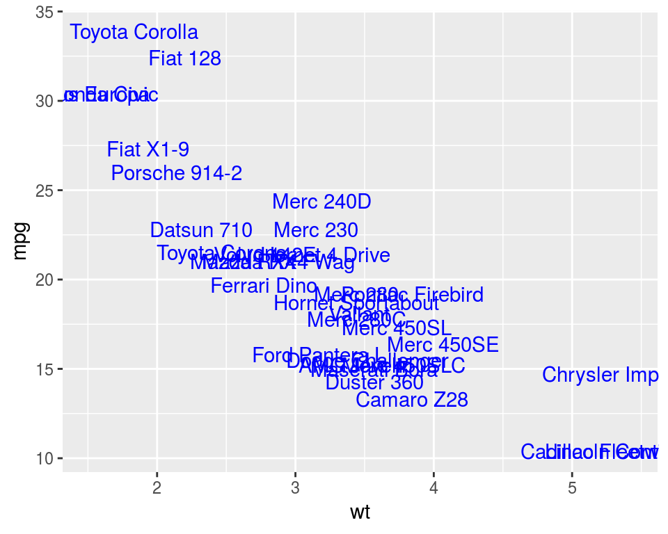

```r
ggplot(mtcars, aes(x = wt, y = mpg, fill = cyl)) + geom_text(label=rownames(mtcars), col="blue")
```

Variables in a data frame are mapped to aesthetics in `aes()`. `(e.g. aes(col = cyl)) within ggplot()`. Visual elements are set by `attributes` in specific `geom layers (geom_point(col = "red"))`.

In this example: adding attributes.

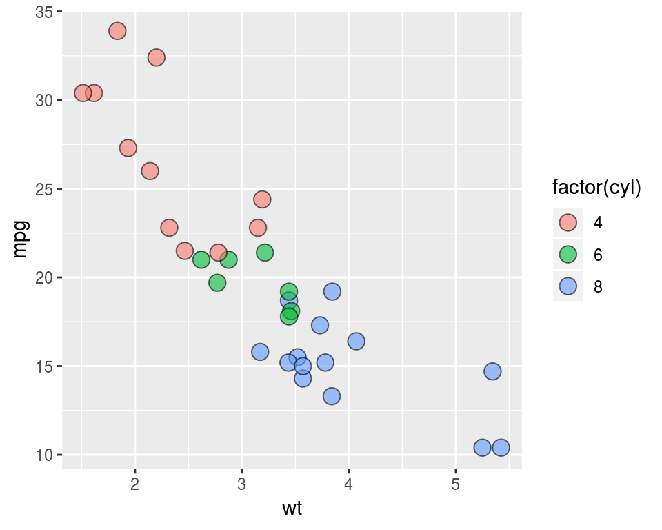

```r
ggplot(mtcars, aes(wt, mpg, fill=factor(cyl))) +
  geom_point(shape=21, size=4, alpha=0.6)
```

In this example we are adding an attibute and WATCH OUT! We are overwritting the colors of the aesthetics.

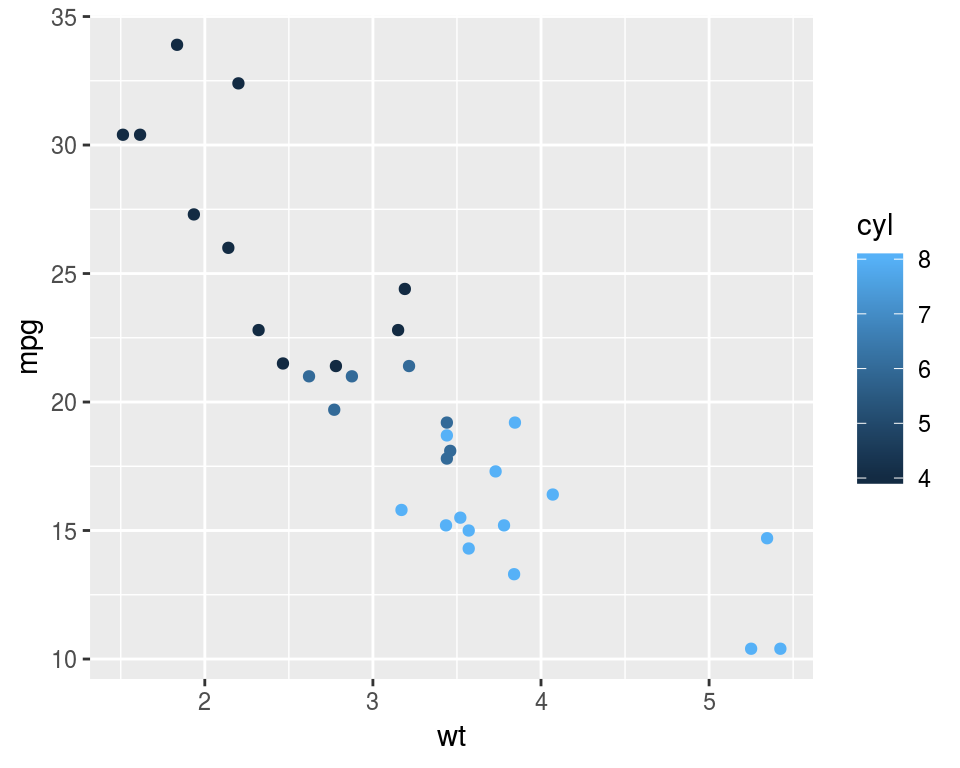

```r
ggplot(mtcars, aes(x= wt, y=mpg, col=cyl))+ geom_point()
```

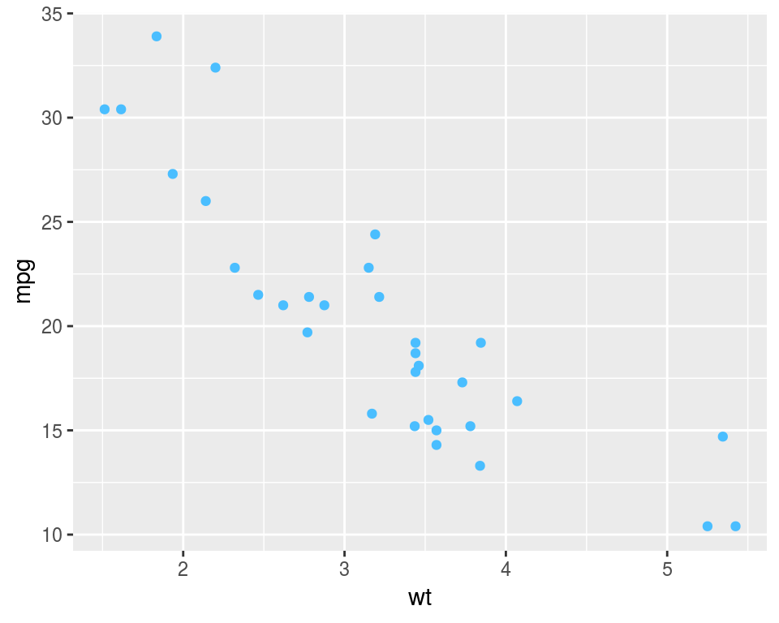

```r
my_color <- "#4ABEFF"
ggplot(mtcars, aes(x= wt, y=mpg, col=cyl))+ geom_point(col=my_color)
```

In this example we are including ONLY aesthetics, not attributes:

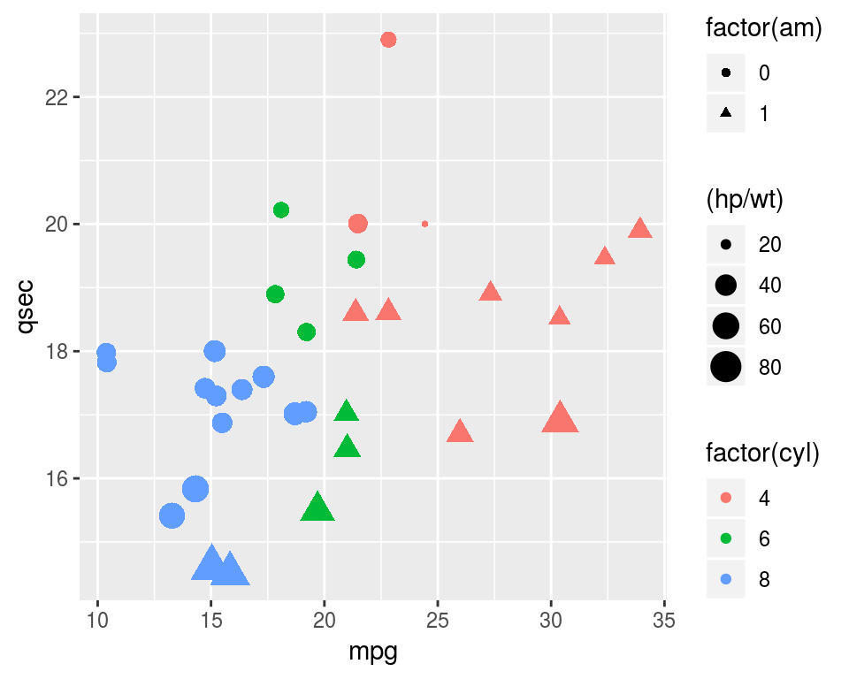

```r
# Map mpg onto x, qsec onto y and factor(cyl) onto col
# Add mapping: factor(am) onto shape
# Add mapping: (hp/wt) onto size
ggplot(mtcars, aes(x=mpg, y=qsec, col=factor(cyl), shape=factor(am), size=(hp/wt))) + geom_point(position = "jitter")
```

**Other type of aesthetics are scales**

- scale_x_“here_define_type_ofvariable”(“nombre del eje”, limits= )
- sacle_y_“here_define_type_ofvariable”(“nombre del eje”, limits= )
- scale_color
- scale_fill
- scale_shape
- scale_linetype

**Position**

Bar plots suffer from their own issues of overplotting, as you’ll see here. Use the “stack”, “fill” and “dodge” positions to reproduce the plot in the viewer.

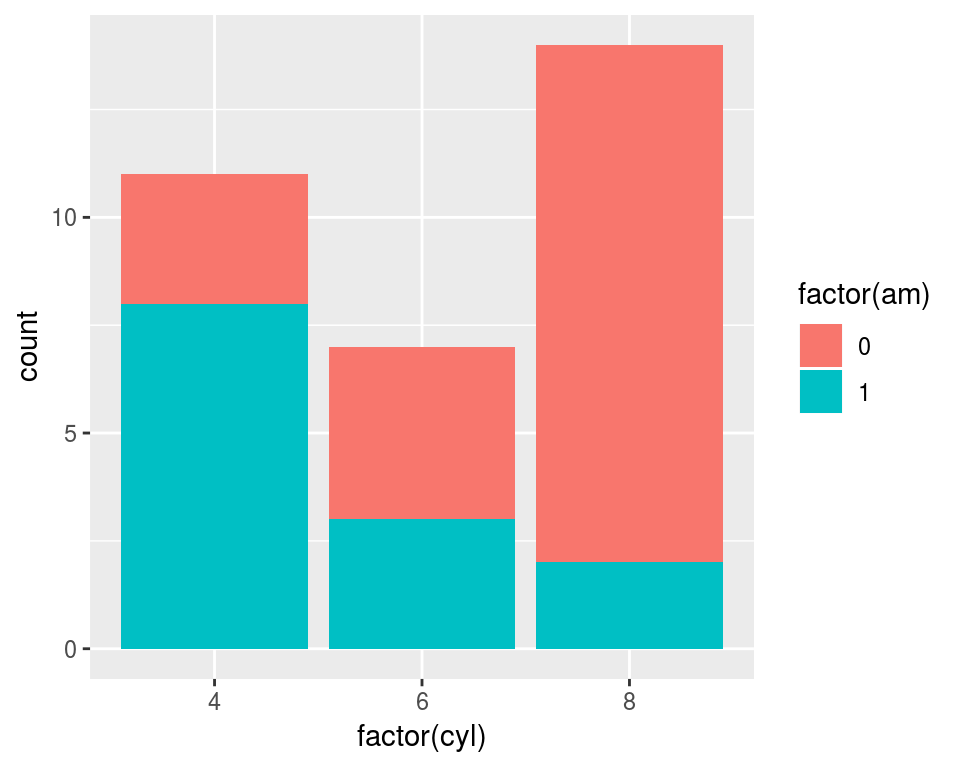

```r
cyl.am <- ggplot(mtcars, aes(x = factor(cyl), fill = factor(am)))
cyl.am + geom_bar(position = "stack") # the one by default
```

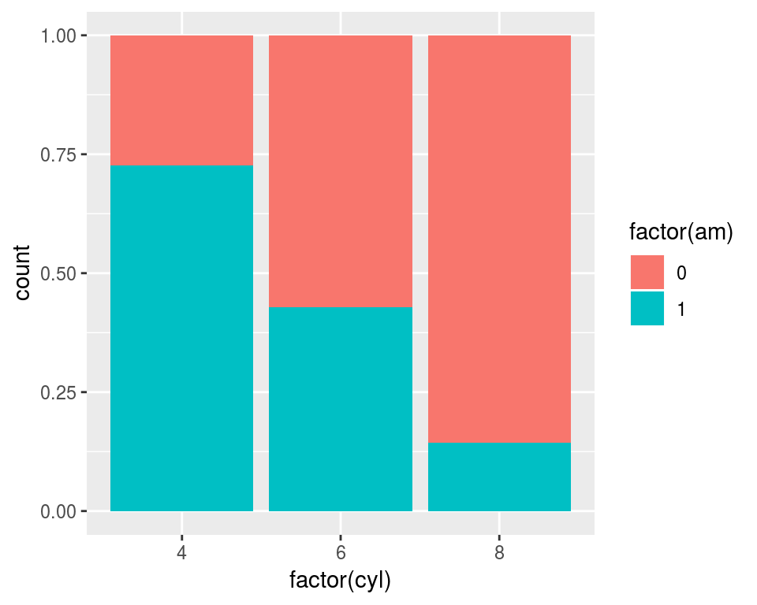

```r
cyl.am + geom_bar(position = "fill")
```

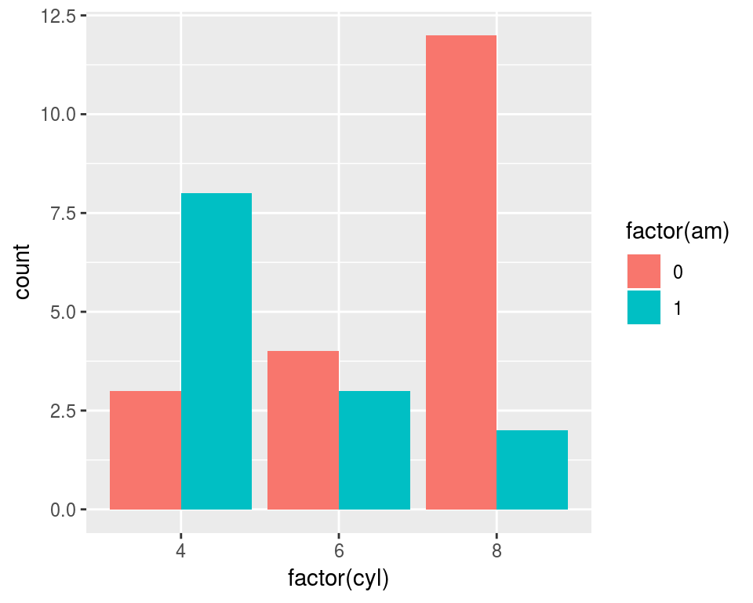

```r
cyl.am + geom_bar(position = "dodge")
```

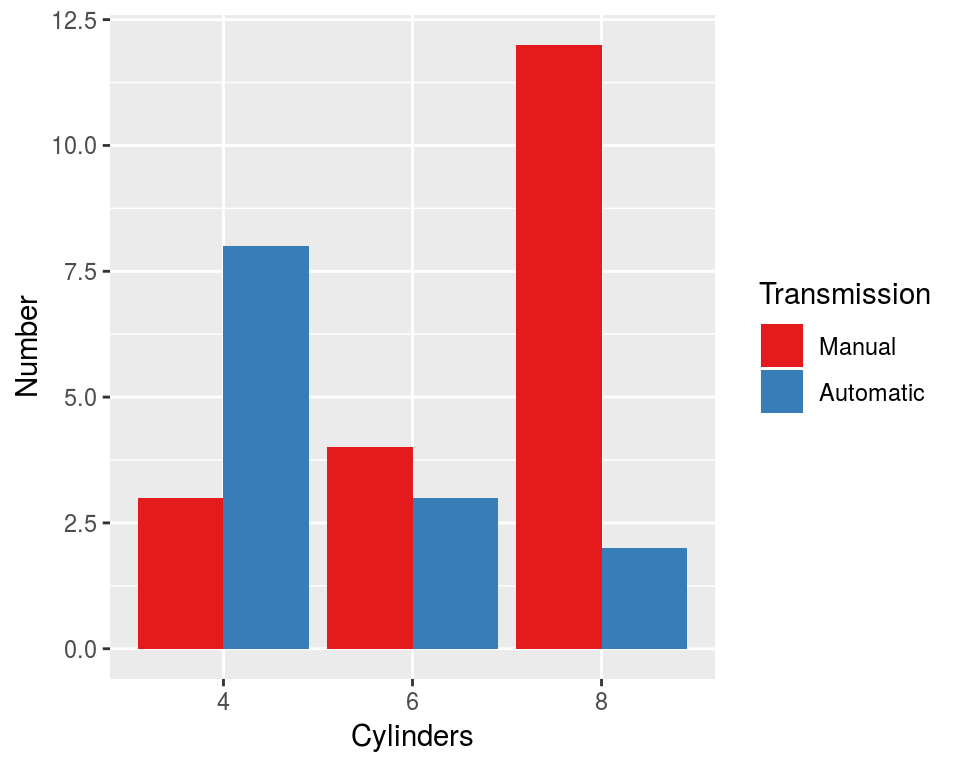

```r
val = c("#E41A1C", "#377EB8")
lab = c("Manual", "Automatic")
cyl.am +
  geom_bar(position = "dodge") +
  scale_x_discrete("Cylinders") +
  scale_y_continuous("Number") +
  scale_fill_manual("Transmission",
                    values = val,
                    labels = lab)
```

What if we don’t want an y_axis: set it to 0 and add jitter to avoid having them over the same line.

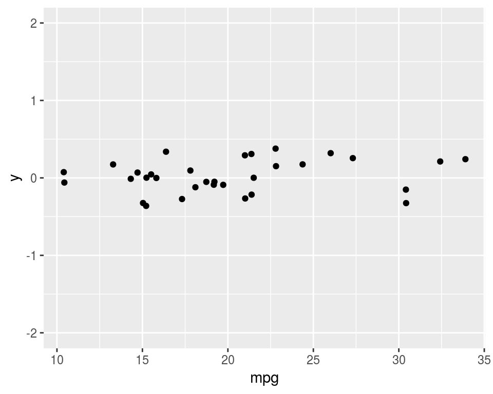

```r
ggplot(mtcars, aes(x = mpg, y = 0)) +
  geom_jitter()+
  scale_y_continuous(limits=c(-2,2))
```

### **Geometries**

37 geometries, but the most common are: Scatter Plots, Bar Plots and Line Plots.

#### Scatter Plot

We can add more than one geom_layer and add new data.

##### geom_jitter()

Notice that jitter can be:

```
  1) an argument in geom_point(position = 'jitter'),

  2) a geom itself, geom_jitter(), or

  3) a position function, position_jitter(0.1)
```

Adjust the dispersion with the argument `width` takes values from 0-1

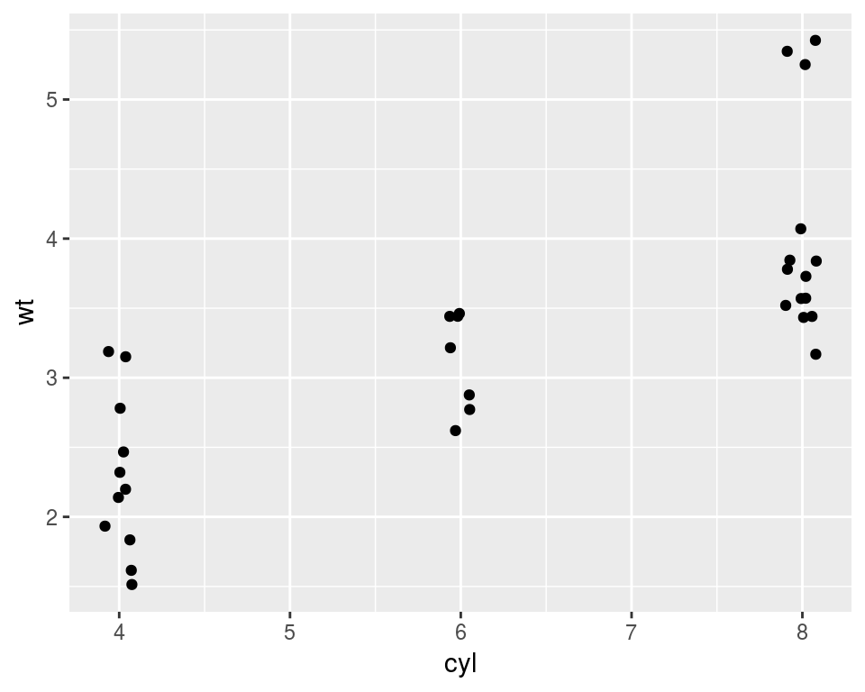

```r
ggplot(mtcars, aes(x = cyl, y = wt)) +
  geom_jitter(width=0.1)
```

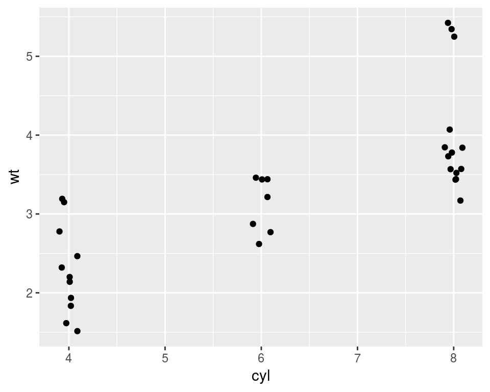

```r
#Alternative text could be inserting the jitter in the geom_point(position argument)

ggplot(mtcars, aes(x = cyl, y = wt)) +
  geom_point(position = position_jitter(0.1))
```

More examples of how useful are adjustments inside the geometries:

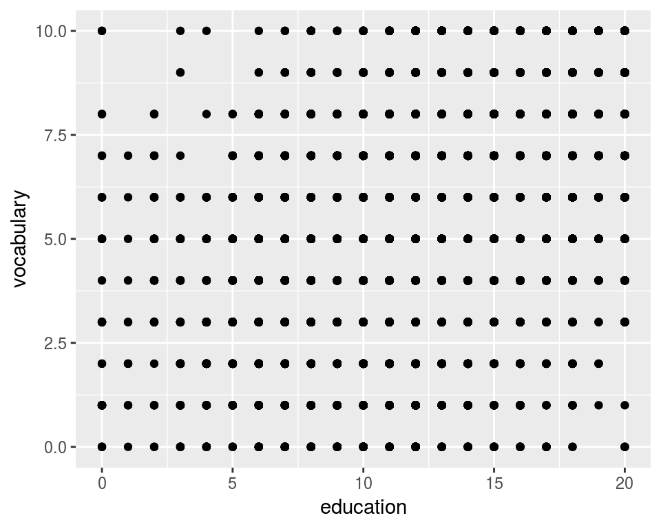

```r
library(carData)
ggplot(Vocab, aes(x=education, y=vocabulary))+geom_point()
```

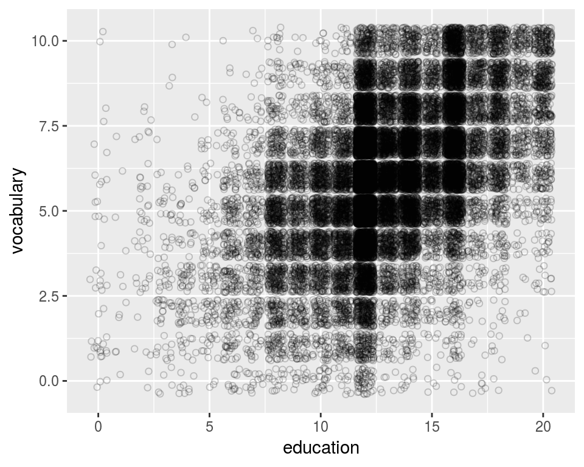

```r
#Obviously due to the not continuous variables they appear all overplotted.

ggplot(Vocab, aes(x=education, y=vocabulary))+geom_jitter(alpha=0.2, shape=1)
```

#### Bar Plot

##### Histogram

Plot statistical function, there are many ways to do binning, but there is not a best way.

**The x axis/aesthetic**: The documentation for `geom_histogram()` states the argument `stat = "bin"` as a default. Recall that histograms cut up a continuous variable into discrete bins - thats what the stat “bin” is doing. You always get 30 evenly-sized bins by default, which is specified with the default argument `binwidth = range/30`. This is a pretty good starting point if you don’t know anything about the variable being ploted and want to start exploring.

**The y axis/aesthetic**: `geom_histogram()` only requires one aesthetic: `x`. But there is clearly a `y` axis on your plot, so where does it come from? Actually, there is a variable mapped to the y aesthetic, it’s called `..count...` When `geom_histogram()` executed the binning statistic (see above), it not only cut up the data into discrete bins, but it also counted how many values are in each bin. So there is an internal data frame where this information is stored. The `..` calls the variable `count` from this internal data frame. This is what appears on the `y` aesthetic. But it gets better! The density has also been calculated. This is the proportional frequency of this bin in relation to the whole data set. You use `..density..` to access this information.

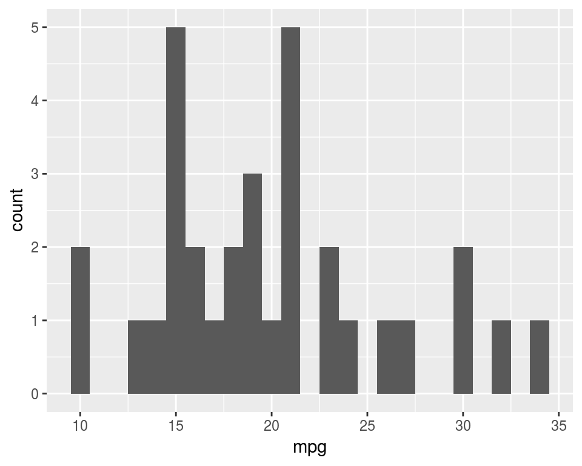

```r
#histogram with counter
ggplot(mtcars, aes(mpg)) +
  geom_histogram(binwidth = 1)
```

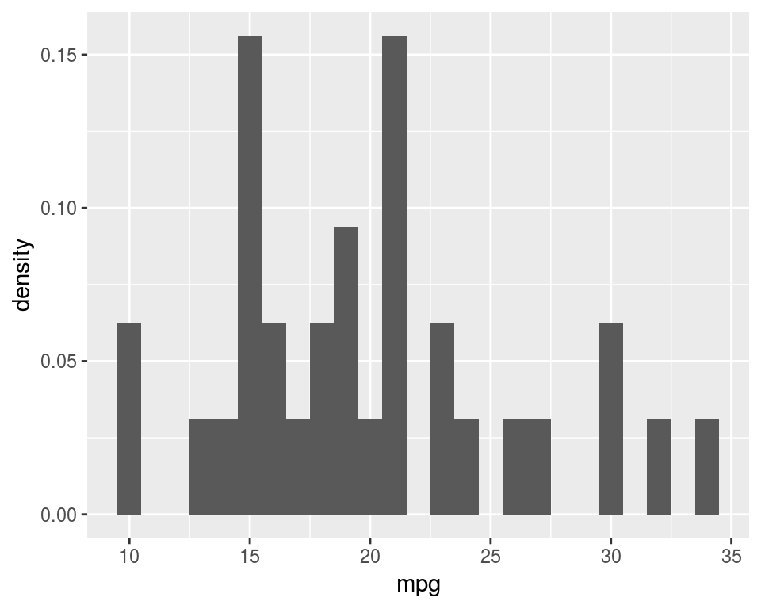

```r
#histogram with density
ggplot(mtcars, aes(mpg)) +
  geom_histogram(aes(y = ..density..), binwidth = 1)
```

A way to see several histograms without overplotting: using position= identity and asigning an alpha.

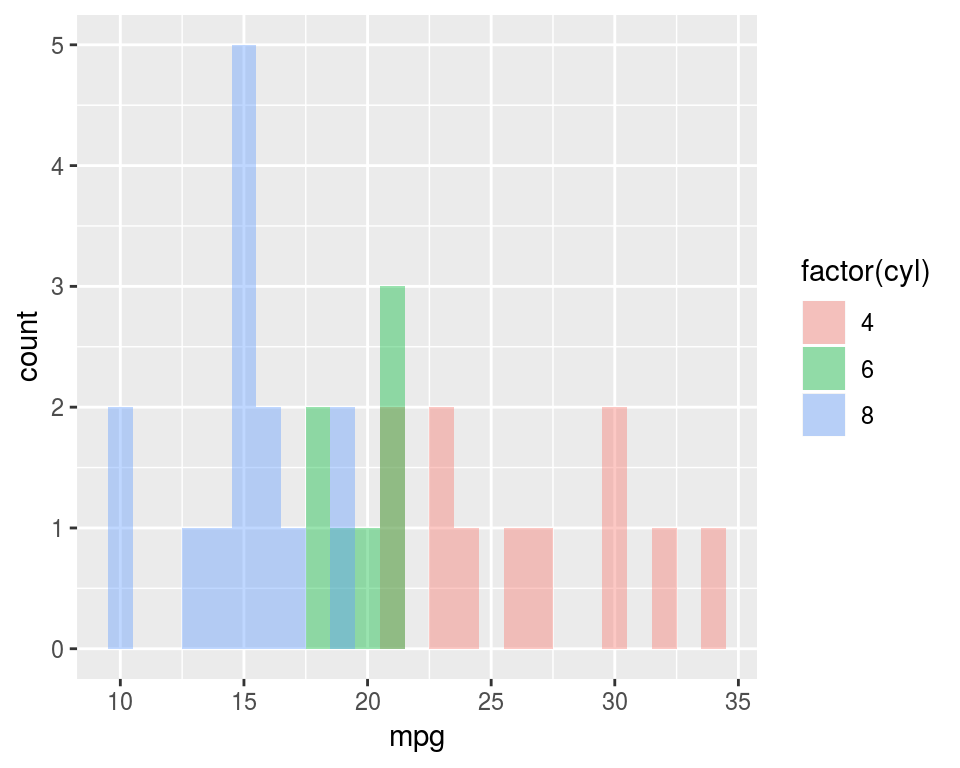

```r
ggplot(mtcars, aes(mpg, fill=factor(cyl))) +
  geom_histogram(binwidth = 1, position="identity",alpha=0.4)
```

##### Bar

Interesting how to set the overlapping columns:

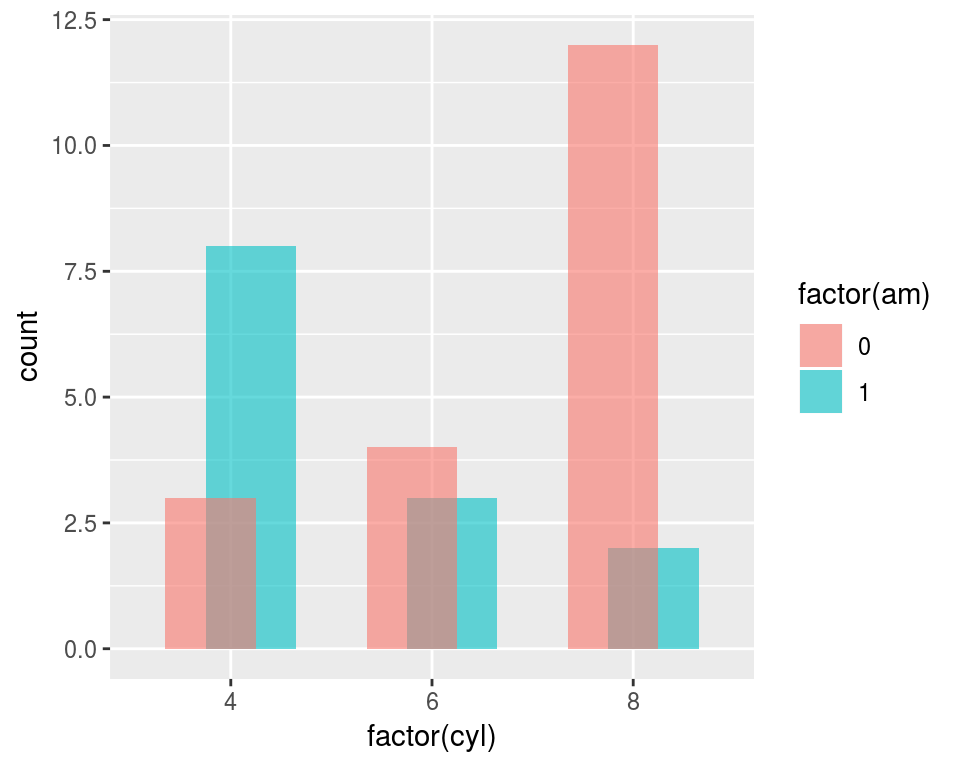

```r
# Define posn_d with position_dodge()
posn_d <- position_dodge(width=0.4)

# 4 - Use posn_d as position and adjust alpha to 0.6
ggplot(mtcars, aes(x = factor(cyl), fill = factor(am))) +
  geom_bar(position = posn_d, alpha=0.6)
```

Overlapping histograms pose similar problems to overlapping bar plots, but there is a unique solution here: a frequency polygon.

This is a geom specific to binned data that draws a line connecting the value of each bin. Like geom_histogram(), it takes a binwidth argument and by default stat = “bin” and position = “identity”.

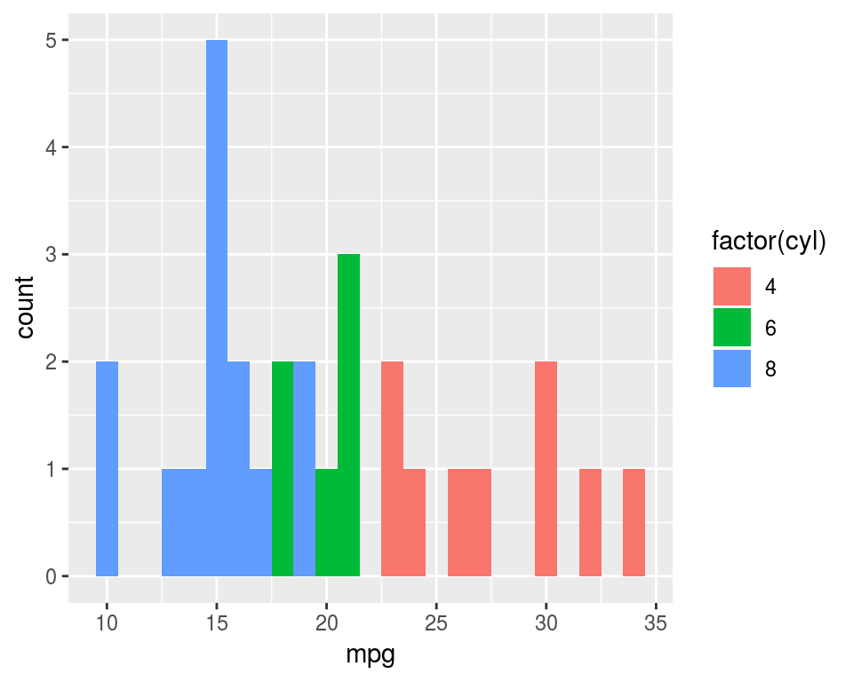

```r
# Change position to identity
ggplot(mtcars, aes(mpg, fill=factor(cyl))) +
  geom_histogram(binwidth = 1, position="identity")
```

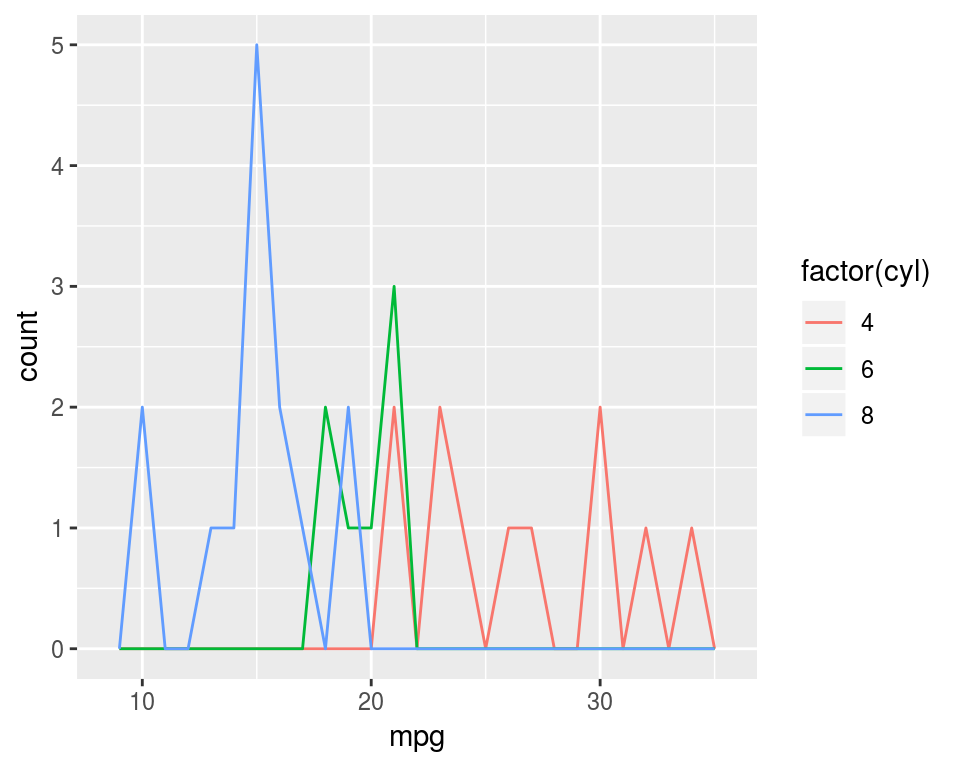

```r
# Change geom to freqpoly (position is identity by default)
ggplot(mtcars, aes(mpg, col=factor(cyl))) +
  geom_freqpoly(binwidth = 1)
```

How to choose apply a range of colours, read the warning: we ended up with an incomplete bar plot. This was because for continuous data, the default RColorBrewer palette that scale_fill_brewer() calls is “Blues”. There are only 9 colours in the palette, and since you have 11 categories, your plot looked strange.

```
## Warning in RColorBrewer::brewer.pal(n, pal): n too large, allowed maximum for palette Blues is 9
## Returning the palette you asked for with that many colors
```

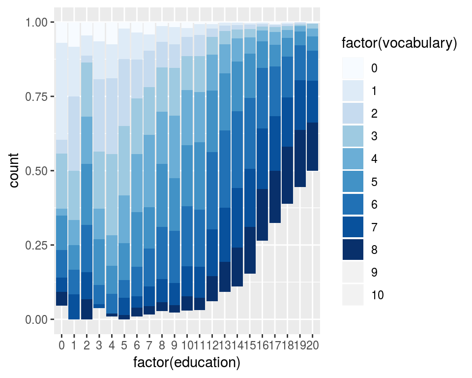

```r
# Plot education on x and vocabulary on fill
# Use the default brewed color palette
ggplot(Vocab, aes(x=factor(education), fill=factor(vocabulary)))+
  geom_bar(position="fill")+
  scale_fill_brewer()
```

The solution:

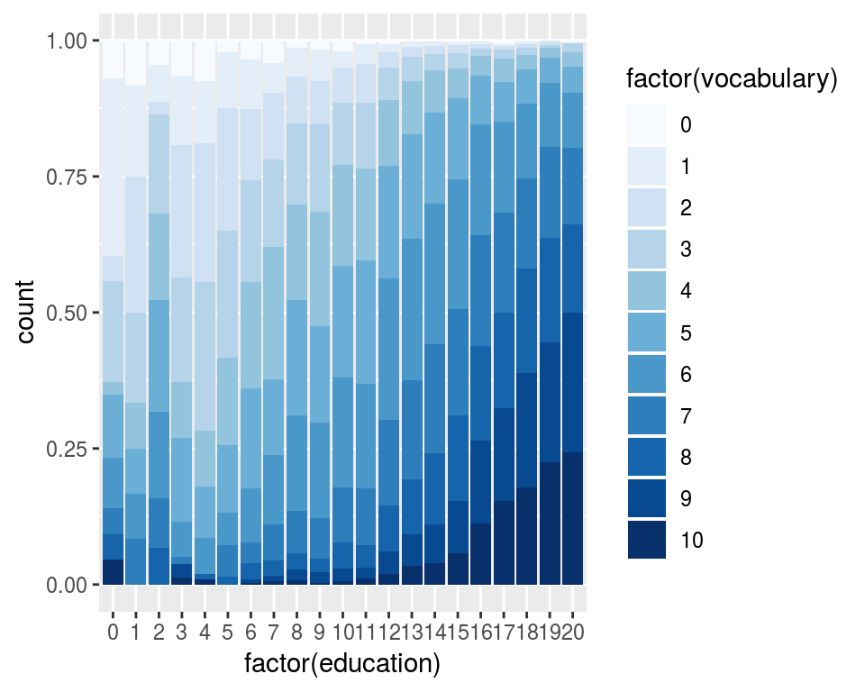

```r
library(RColorBrewer)
# Definition of a set of blue colors
blues <- brewer.pal(9, "Blues")

# Make a color range using colorRampPalette() and the set of blues
blue_range <- colorRampPalette(blues)

# Use blue_range to adjust the color of the bars, use scale_fill_manual()
ggplot(Vocab, aes(x = factor(education), fill = factor(vocabulary))) +
  geom_bar(position = "fill") +
  scale_fill_manual(values = blue_range(11))
```

#### Line Plot

Special for time series

`economics` data frame contains time series for unemployment and population statistics from the Federal Reserve Bank of St. Louis in the US. The data is contained in the `ggplot2 package`.

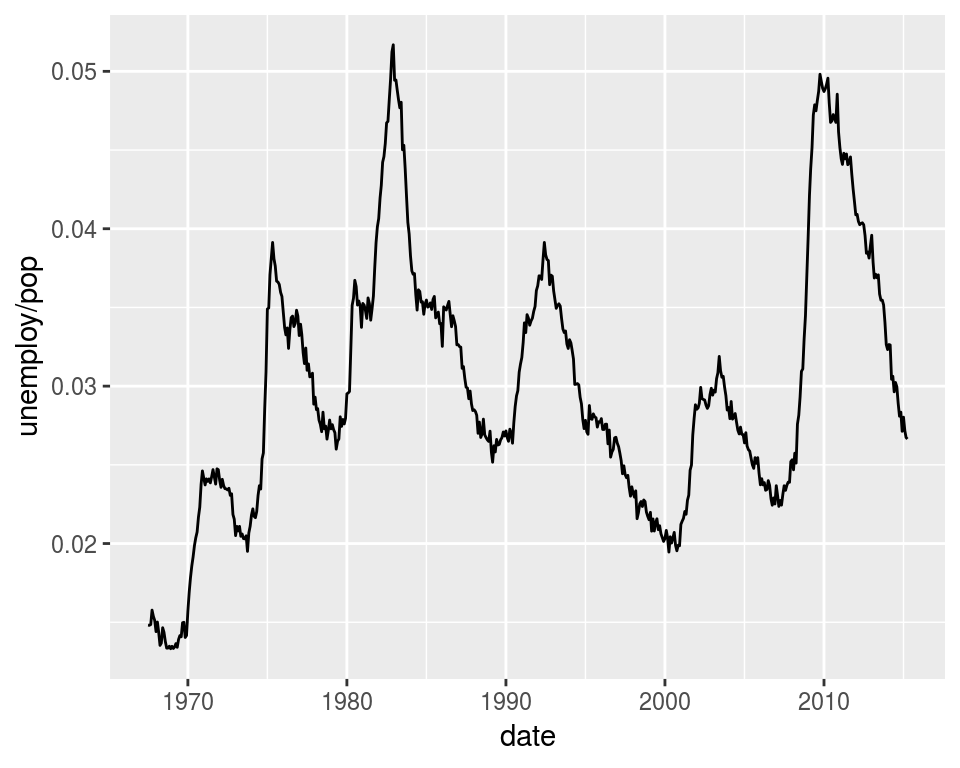

```r
ggplot(economics, aes(x = date, y = unemploy/pop)) + geom_line()
```

```r
library(tidyverse)
recesscsv <- read_csv("Data/recess.csv")
head(recesscsv)
```

```
## # A tibble: 6 x 3
##      X1 begin      end
##   <int> <date>     <date>
## 1     1 1969-12-01 1970-11-01
## 2     2 1973-11-01 1975-03-01
## 3     3 1980-01-01 1980-07-01
## 4     4 1981-07-01 1982-11-01
## 5     5 1990-07-01 1991-03-01
## 6     6 2001-03-01 2001-11-01
```

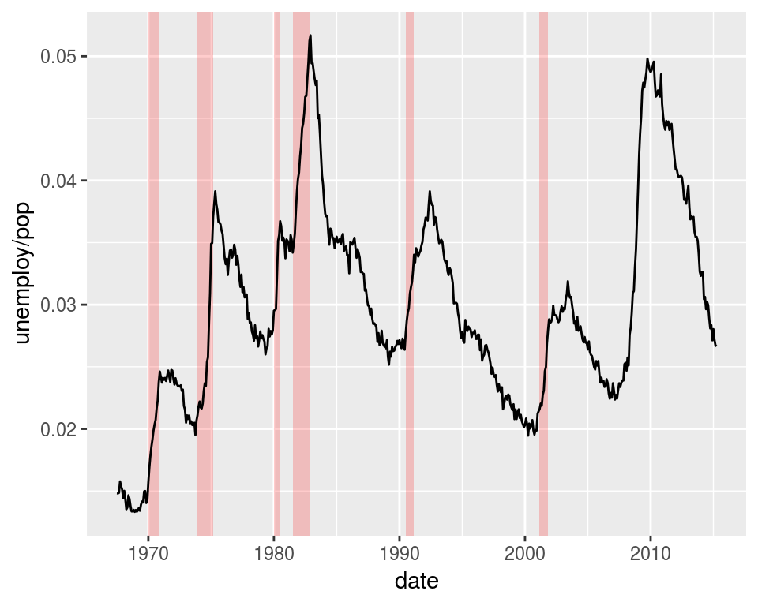

```r
ggplot(economics, aes(x = date, y = unemploy/pop)) +
  geom_rect(data = recesscsv,
         aes(xmin = begin, xmax = end, ymin = -Inf, ymax = +Inf),
         inherit.aes = FALSE, fill = "red", alpha = 0.2) +
  geom_line()
```

To get a multiple time series plot, however, both Year and Species should be in their own column. You need tidy data: one variable per column. Once you have that you can get the plot shown in the viewer by mapping Year to the x aesthetic and Species to the color aesthetic.

You’ll use the gather() function of the tidyr package, which is already loaded for you.

```r
# Check the structure as a starting point
fish.species<-read.csv("Data/fishspecies.csv")[,2:9]
str(fish.species)
```

```
## 'data.frame':    61 obs. of  8 variables:
##  $ Year    : int  1950 1951 1952 1953 1954 1955 1956 1957 1958 1959 ...
##  $ Pink    : int  100600 259000 132600 235900 123400 244400 203400 270119 200798 200085 ...
##  $ Chum    : int  139300 155900 113800 99800 148700 143700 158480 125377 132407 113114 ...
##  $ Sockeye : int  64100 51200 58200 66100 83800 72000 84800 69676 100520 62472 ...
##  $ Coho    : int  30500 40900 33600 32400 38300 45100 40000 39900 39200 32865 ...
##  $ Rainbow : int  0 100 100 100 100 100 100 100 100 100 ...
##  $ Chinook : int  23200 25500 24900 25300 24500 27700 25300 21200 20900 20335 ...
##  $ Atlantic: int  10800 9701 9800 8800 9600 7800 8100 9000 8801 8700 ...
```

```r
# Use gather to go from fish.species to fish.tidy
fish.tidy <- gather(fish.species, Species, Capture, -Year)
```

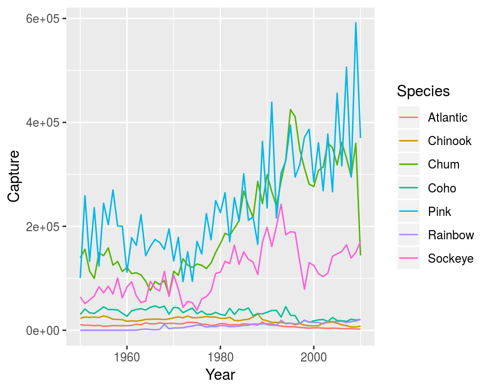

```r
ggplot(fish.tidy, aes(x = Year, y = Capture, col=Species)) + geom_line()
```

#### Dot Plot

Some naming conventions:

```
Scatter plots:
Continuous x, continuous y.
Dot plots:
Categorical x, continuous y.
```

You use geom_point() for both plot types. Jittering position is set in the geom_point() layer.

One thing to notice is that geom_dotplot() uses a different plotting symbol to geom_point(). For these symbols, the color aesthetic changes the color of its border, and the fill aesthetic changes the color of its interior.

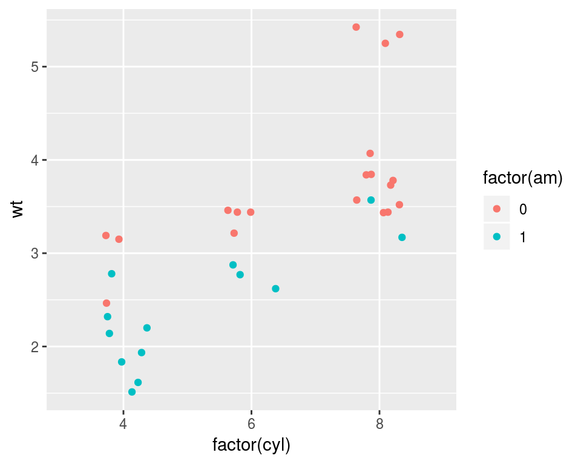

```r
# "Basic" dot plot, with geom_point():
ggplot(mtcars, aes(factor(cyl), wt, col = factor(am))) +
  geom_point(position = position_jitter(0.2, 0))
```

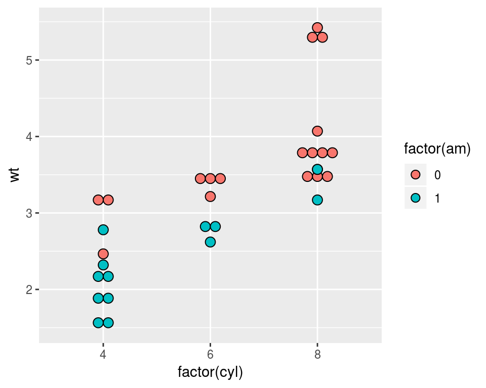

```r
# 1 - "True" dot plot, with geom_dotplot():
ggplot(mtcars, aes(factor(cyl), wt, fill = factor(am))) +
  geom_dotplot(stackdir = "center", binaxis = "y")
```